# Class prediction using random forest model

AngieMolina

7/07/2020

## Overview

Today its very common for people to use devices and take measurements regularly to quantify how much of a particular activity they do, but they rarely quantify how well they do it. In this project, the goal is to use data from accelerometers on the belt, forearm, arm, and dumbell of 6 participants. They were asked to perform barbell lifts correctly and incorrectly in 5 different ways. More information is available from the website here: http://groupware.les.inf.puc-rio.br/har (see the section on the Weight Lifting Exercise Dataset).

The data for this project and some assumptions used come from this source: http://groupware.les.inf.puc-rio.br/har.

Velloso, E.; Bulling, A.; Gellersen, H.; Ugulino, W.; Fuks, H. Qualitative Activity Recognition of Weight Lifting Exercises. Proceedings of 4th International Conference in Cooperation with SIGCHI (Augmented Human ’13) . Stuttgart, Germany: ACM SIGCHI, 2013.

## Basic exploratory and tidy data analysis

For understanding the data, the dataset is loaded, read and visualized.

```r
library (caret)
library (randomForest)
library(rpart)
```

```r
print (c("Train data:", dim(trainData)))
```

```
## [1] "Train data:" "19622"       "160"
```

```r
print (c("Test data:", dim(testData)))
```

```
## [1] "Test data:" "20"         "160"
```

```r
##Tidy data, remove Nas and select variables for analysis
trainD <- trainData[, colSums(is.na(trainData)) == 0]
test <- testData[, colSums(is.na(testData)) == 0]
trainD <- trainD[, -c(1:7)]
test <- test[, -c(1:7)]
```

The training dataframe has 19622 observations and 160 variables. The test data has 20 observations and 160 variables. From both data sets de Nas and associated columns are removed. Finally, taking into account the article, the first 7 columns are removed since they don’t contain information that contribute to this analysis.

## Model selection

Once the data sets are organized, the training data is divided in 2 parts, one for training the model and the other for validation (will be used for crossvalidation purposes). In this case since I don’t know which is the best model, I will try 2 models with high accuracy for this type of data. For this selection I take the validation set and divide it in two sets one for training and the other for validation.

```r
set.seed(12345)
inTrain <- createDataPartition(trainD$classe, p = 3 / 4, list = FALSE)
trainD <- trainD[inTrain, ]
testV <- trainD[-inTrain, ]
print (c("Train data:", dim(trainD)))
```

```
## [1] "Train data:" "14718"       "53"
```

```r
print (c("Validation data:", dim(testV)))
```

```
## [1] "Validation data:" "3683"             "53"
```

```r
print (c("Test data:", dim(test)))
```

```
## [1] "Test data:" "20"         "53"
```

```r
##Create a dataset for evaluating models
inTrainE <- createDataPartition(testV$classe, p = 3 / 4, list = FALSE)
trainDE <- testV[inTrainE, ]
testVE <- testV[-inTrainE, ]

##Try 2 different models with the new data for model selection
modelRfE <- train(classe ~ ., data = trainDE, method = "rf")
modelGbmE <-
  train(classe ~ .,
        data = trainDE,
        method = "gbm",
        verbose = FALSE)

predictRfE <- predict(modelRfE, testVE)
predictGbmE <- predict(modelGbmE, testVE)

cMrf <-
  confusionMatrix(table(predictRfE, testVE$classe))$overall['Accuracy']
cMgbm <-
  confusionMatrix(table(predictGbmE, testVE$classe))$overall['Accuracy']

print (c("Random forest accuracy:", round(cMrf, 4)))
```

```
##                                            Accuracy
## "Random forest accuracy:"                  "0.9597"
```

```r
print (c("Gradient boosting accuracy:", round(cMgbm,4)))
```

```
##                                                    Accuracy
## "Gradient boosting accuracy:"                      "0.9271"
```

The accuracy(sensibility) results for the random forest model was 0.96, and for the gradient boosting accuracy was 0.927. Then, I select the random forest model for this project.

## Prediction results

```r
set.seed(56789)
ctrl = trainControl(method="cv", 5)
modelFit <-
  train(classe ~ .,
        data = trainD,
        method = "rf",
        ntree = 250)
modelFit
```

```
## Random Forest
##
## 14718 samples
##    52 predictor
##     5 classes: 'A', 'B', 'C', 'D', 'E'
##
## No pre-processing
## Resampling: Bootstrapped (25 reps)
## Summary of sample sizes: 14718, 14718, 14718, 14718, 14718, 14718, ...
## Resampling results across tuning parameters:
##
##   mtry  Accuracy   Kappa
##    2    0.9890878  0.9861896
##   27    0.9886895  0.9856868
##   52    0.9791310  0.9735909
##
## Accuracy was used to select the optimal model using the largest value.
## The final value used for the model was mtry = 2.
```

```r
predictV <- predict(modelFit, testV)
confusionMatrix(table(predictV, testV$classe))
```

```
## Confusion Matrix and Statistics
##
##
## predictV    A    B    C    D    E
##        A 1052    0    0    0    0
##        B    0  696    0    0    0
##        C    0    0  651    0    0
##        D    0    0    0  594    0
##        E    0    0    0    0  690
##
## Overall Statistics
##
##                Accuracy : 1
##                  95% CI : (0.999, 1)
##     No Information Rate : 0.2856
##     P-Value [Acc > NIR] : < 2.2e-16
##
##                   Kappa : 1
##
##  Mcnemar's Test P-Value : NA
##
## Statistics by Class:
##
##                      Class: A Class: B Class: C Class: D Class: E
## Sensitivity            1.0000    1.000   1.0000   1.0000   1.0000
## Specificity            1.0000    1.000   1.0000   1.0000   1.0000
## Pos Pred Value         1.0000    1.000   1.0000   1.0000   1.0000
## Neg Pred Value         1.0000    1.000   1.0000   1.0000   1.0000
## Prevalence             0.2856    0.189   0.1768   0.1613   0.1873
## Detection Rate         0.2856    0.189   0.1768   0.1613   0.1873
## Detection Prevalence   0.2856    0.189   0.1768   0.1613   0.1873
## Balanced Accuracy      1.0000    1.000   1.0000   1.0000   1.0000
```

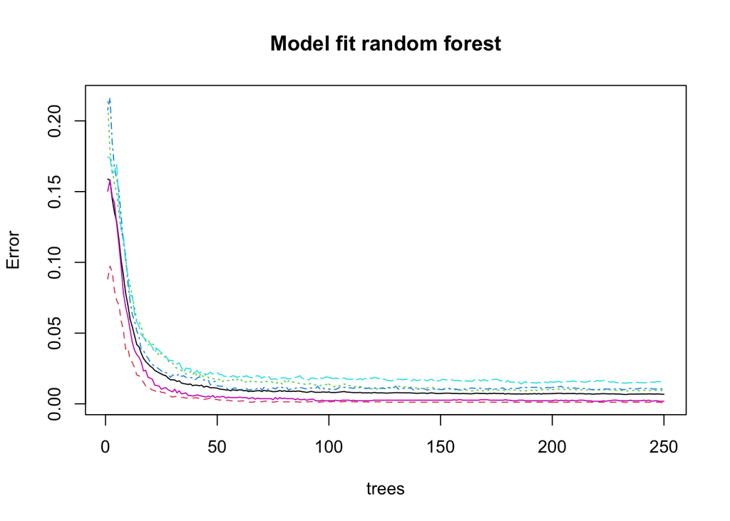

```r
plot(modelFit$finalModel, main = "Model fit random forest")
```

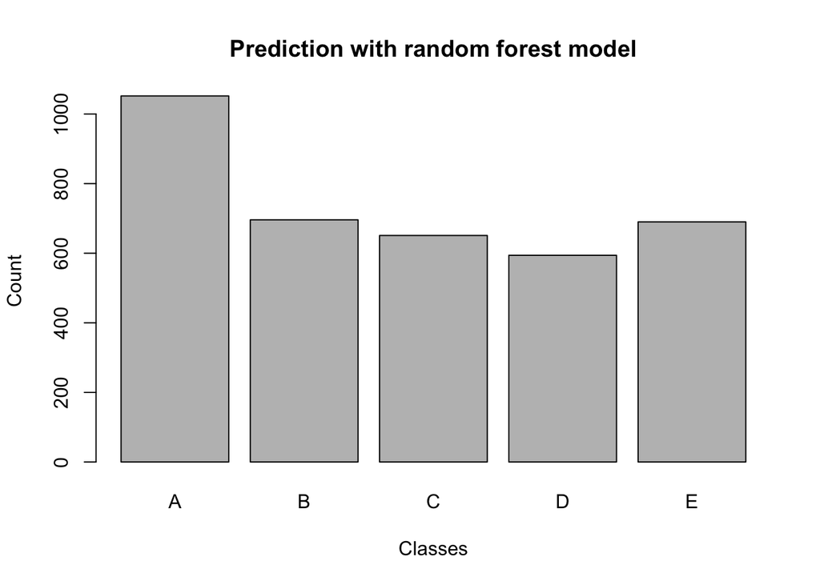

```r
plot(predictV,
     xlab = "Classes",
     ylab = "Count",
     main = "Prediction with random forest model")
```

## Test data prediction

Once the selected model was evaluated with the cross validation, the test data is predicted.

```r
predictT <- predict(modelFit, test)
predictT
```

```
##  [1] B A B A A E D B A A B C B A E E A B B B
## Levels: A B C D E
```